# Chapter 4 - Geocentric Models

Linear Models are the geocentric models for applied statistics, i.i. simple, mostly wrong but works if calibrated correctly and one knows the assumptions. It is a family of simple stats models which attempt to learn about the mean and variance of some measurement, using an additive combination of other measurements. One LM could correspond to several process models and that is fine as we don’t care. LM make assumption of using gaussian distribution to quantify their uncertainity about the measurement of interest.

## 0.1 Normal Distribution

#### 0.1.0.1 By sum

Simulate 1e4 times a process where a person moves left or right with uniformly distributed steps 16 times and observe the resulting deviation

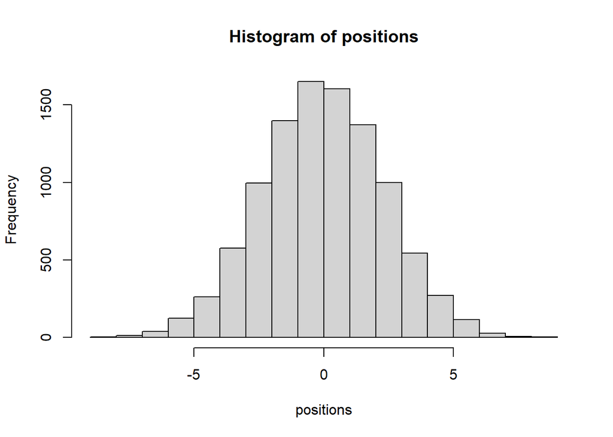

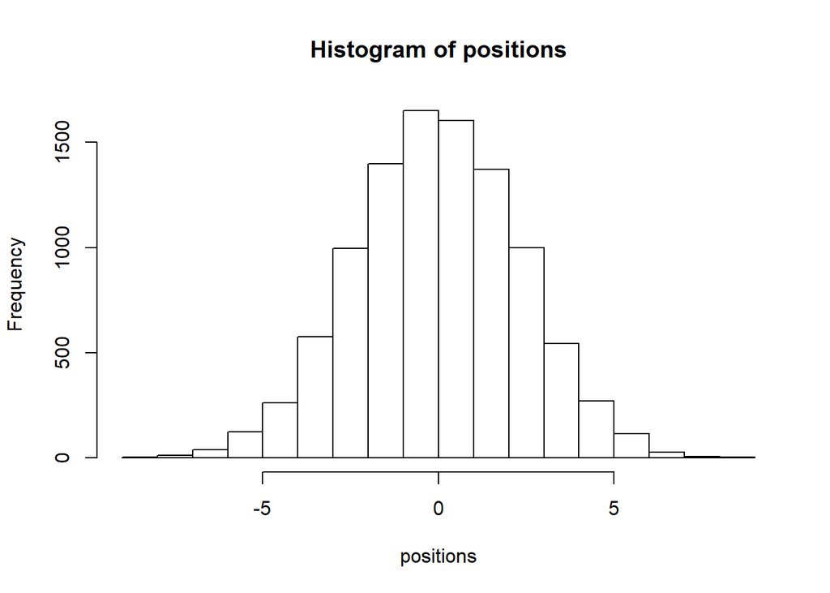

```r
positions <- replicate(1e4, sum(runif(n=16, min = -1, max = 1)))
plot(hist(positions))
```

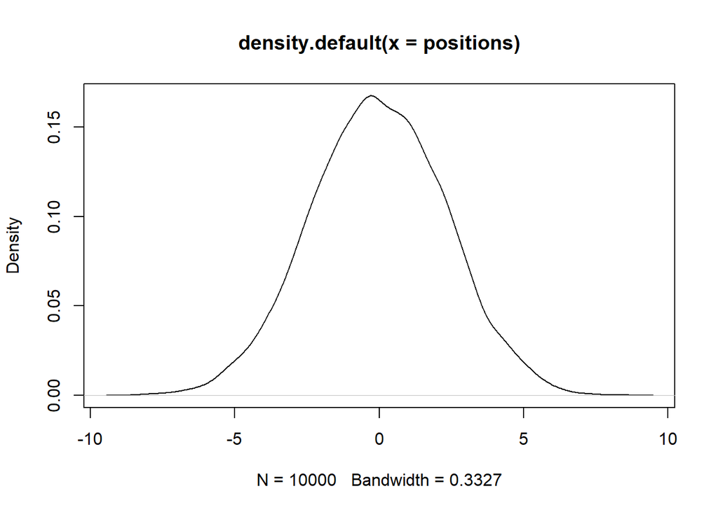

```r
plot(density(positions))
```

#### 0.1.0.2 By Product

Suppose an organism grows by a dozen loci such that they each contributes a percentage to final growth (by multiplication). So, if each lous has ~Unif(0, 0.1) then what is value of final growth rate?

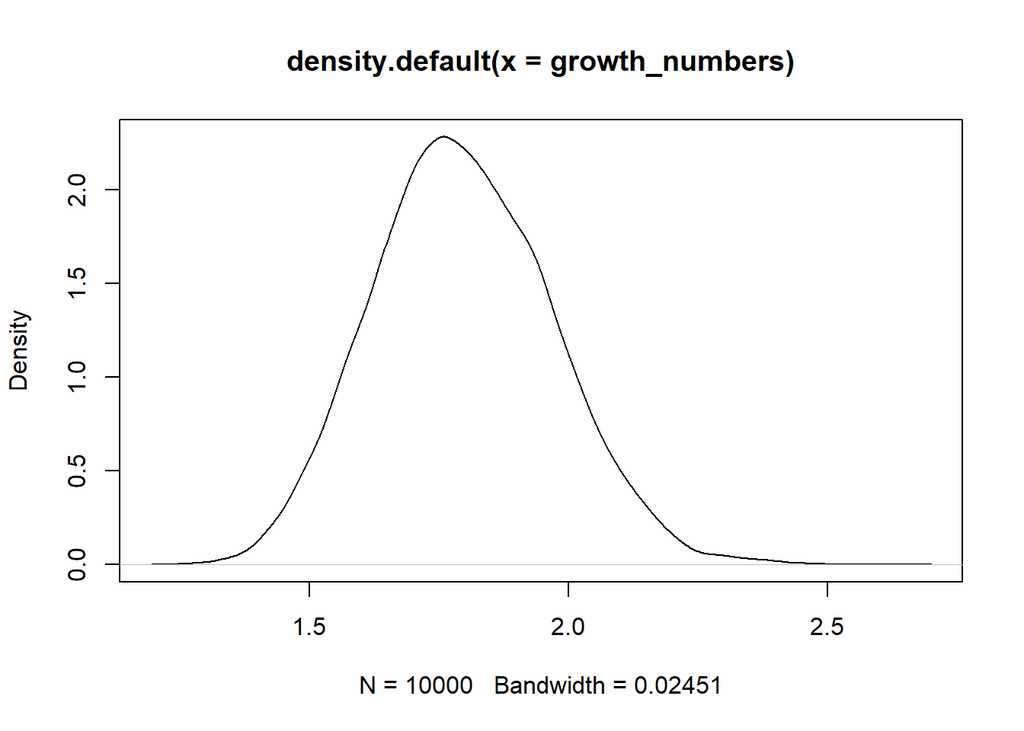

```r
growth_numbers = replicate(1e4, prod(1+runif(n=12, min=0, max=0.1)))
plot(density(growth_numbers))
```

Again, looks like a Gaussian *_*. Why’s this? Coz product of 1+small_numbers is approx their sum, this won’t hold with larger numbers

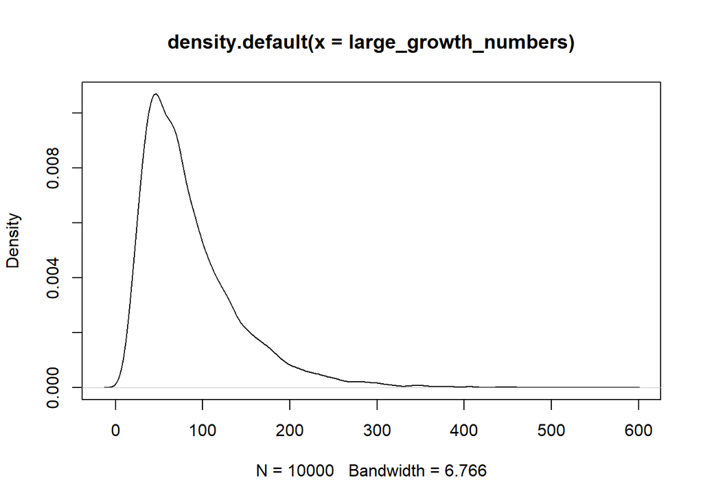

```r
large_growth_numbers = replicate(1e4, prod(1+runif(n=12, min=0, max=0.9)))
plot(density(large_growth_numbers))
```

Nope, not looking like Gaussian at all.

#### 0.1.0.3 Normal by log-multiplication

However, large number multiplications on log scale? (coz, log of mults = sum of logs !)

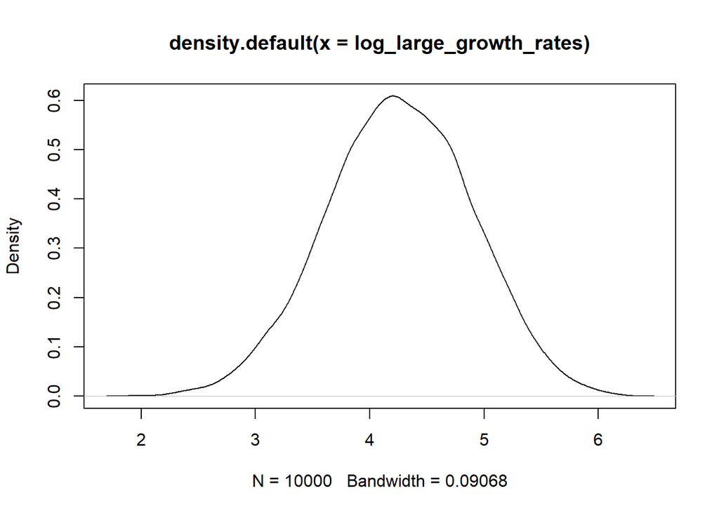

```r
log_large_growth_rates = replicate(1e4, log(prod(1+runif(12, min=0, max=0.9))))
plot(density(log_large_growth_rates))
```

And .. our Gaussians are back, note that there’s nothing wrong with measuring output as log, it’s just a transformation and can be,very rightly done. Many things are measure on this scale, e.g., earthquakes, information, Covd rise (!) etc.

### 0.1.1 Surely a few graphs don’t prove anything? - Other justifications of using Normal

#### 0.1.1.1 Ontological Justification (Gaussian is common in natural processes)

Gaussians occur commonly in nature as a result of processes which involve averaging over large number of fluctuations. As this arises over large numbers, we cannot and should not expect Gaussian based models to identify micro processes. Also, Gaussians are a member of the exponential family of distributions which also includes Poissons, Gamma, Exponentials etc. All of these occur in nature, not just Gassian (e.g., Covid cases rise exponentially in initial stages)

#### 0.1.1.2 Epistemological Justification (Sometimes, Gaussian is best we can do with our information)

If all we know about a list of measures is their mean and std. then assuming Gaussian adds no further assumptions and hence, is more accurate of our understanding.

> Gaussian is the most natural expression of our state of ignorance, because if all we’re willing to assume is that a measure has finite vqariance, the Gaussian distribution is the shape that can be realized in the largets number of ways and does not introduce and new assumptions.

Also, don’t randomly apply Gaussians everywhere as there are thick tailed distributions which assign decent probability mass to high deviation outcomes which will completely surprise you if you use Gaussian. E.g., Stock MArket returns over a short time are Gaussian, but over medium and long term are defintiely not!

## 0.2 Language of Models

So how can we define models such that a few lines can tell everything about our assumptions and all our variables?

$$\begin{align*}
y_i &\sim Normal({\mu}_i, \sigma) \\
{\mu}_i &= \beta x_i \\
\beta &\sim Normal(0, 10) \\
\sigma &\sim Exponential(1) \\
x_i &\sim Normal(0, 1) \\
\end{align*}$$

1. Include set of variables we wish to understand - observable (data) and unobservable (parameters)
2. Each variable is either a function of others (like $\mu_i$) or has a distribution ($\sigma$). Stochastic variables are ones which don’t have deterministic values, like $\sigma$
3. Combined as above, all the variables define a join generative model which can be used both to simulate hypothetical observations and analyze real ones.

## 0.3 Show a man a model and he will learn better

Let’s model the height of a particular tribe !Kung San using what we’ve learnt till now

```r
library(rethinking)
data(Howell1)
d <- Howell1
# Get the heights of people with age>18
d2 <- d[d$age>=18, ]
```

Model

$$\begin{align*}
h_i &\sim Normal(\mu, \sigma)\\
\mu &\sim Normal(178, 20) \\
\sigma &\sim Uniform(0, 50) \\
\end{align*}$$

Explaination - We assume height is Normally distributed with some mean and sigma which we have to find. The priors are defined (this is BAyesian analysis after all!)

### 0.3.1 Sanity Checks - Generating data from our generative model

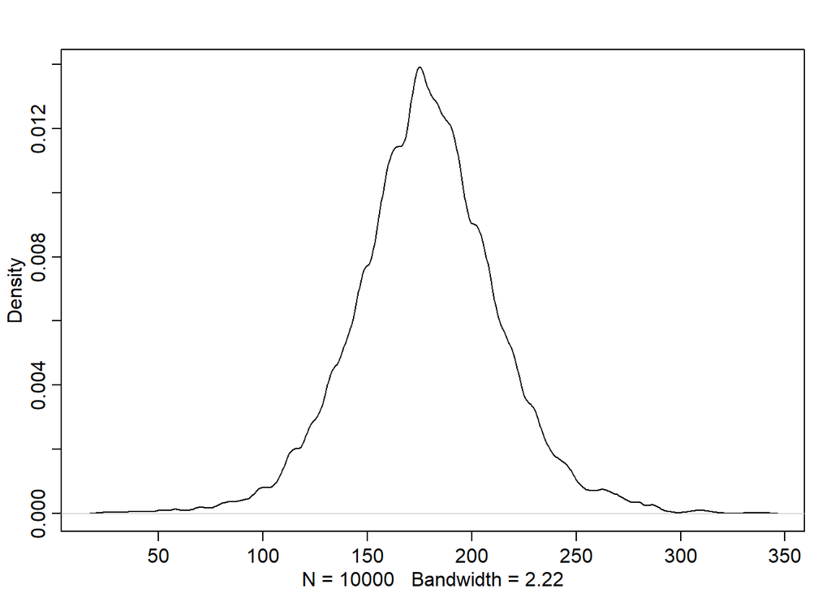

```r
sample_mu <- rnorm(1e4, 178, 20)
sample_sigma <- runif(1e4, 0, 50)
prior_h <- rnorm(1e4, sample_mu, sample_sigma)
dens(prior_h)
```

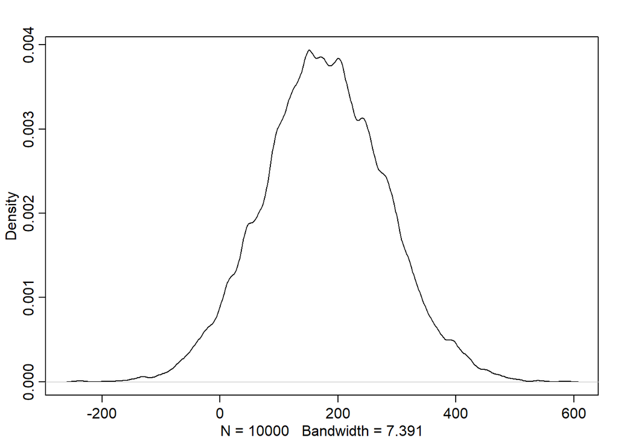

```r
sample_mu <- rnorm(1e4, 178, 100)
sample_sigma<-runif(1e4, 0, 50)
prior_h<- rnorm(1e4, sample_mu, sample_sigma)
dens(prior_h)
```

```r
print("Density of heights above 2.5 m")
```

```
## [1] "Density of heights above 2.5 m"
```

```r
sum(prior_h>250)/length(prior_h)
```

```
## [1] 0.2389
```